# R Notebook

**Principles of Data Visualization and Introduction to ggplot2**

I have provided you with data about the 5,000 fastest growing companies in the US, as compiled by Inc. magazine. lets read this in:

```r
inc <- read.csv("https://raw.githubusercontent.com/charleyferrari/CUNY_DATA_608/master/module1/Data/inc5000_data.csv", header= TRUE)
```

And lets preview this data:

```r
head(inc)
```

|  | Rank | Name | Growth_Rate | Revenue | Industry | Employees | City | State |
| --- | --- | --- | --- | --- | --- | --- | --- | --- |
| 1 | 1 | Fuhu | 421.48 | 1.179e+08 | Consumer Products & Services | 104 | El Segundo | CA |
| 2 | 2 | FederalConference.com | 248.31 | 4.960e+07 | Government Services | 51 | Dumfries | VA |
| 3 | 3 | The HCI Group | 245.45 | 2.550e+07 | Health | 132 | Jacksonville | FL |
| 4 | 4 | Bridger | 233.08 | 1.900e+09 | Energy | 50 | Addison | TX |
| 5 | 5 | DataXu | 213.37 | 8.700e+07 | Advertising & Marketing | 220 | Boston | MA |
| 6 | 6 | MileStone Community Builders | 179.38 | 4.570e+07 | Real Estate | 63 | Austin | TX |

```r
summary(inc)
```

```
      Rank                          Name       Growth_Rate         Revenue
 Min.   :   1   (Add)ventures         :   1   Min.   :  0.340   Min.   :2.000e+06
 1st Qu.:1252   @Properties           :   1   1st Qu.:  0.770   1st Qu.:5.100e+06
 Median :2502   1-Stop Translation USA:   1   Median :  1.420   Median :1.090e+07
 Mean   :2502   110 Consulting        :   1   Mean   :  4.612   Mean   :4.822e+07
 3rd Qu.:3751   11thStreetCoffee.com  :   1   3rd Qu.:  3.290   3rd Qu.:2.860e+07
 Max.   :5000   123 Exteriors         :   1   Max.   :421.480   Max.   :1.010e+10
                (Other)               :4995
                         Industry      Employees                  City          State
 IT Services                 : 733   Min.   :    1.0   New York     : 160   CA     : 701
 Business Products & Services: 482   1st Qu.:   25.0   Chicago      :  90   TX     : 387
 Advertising & Marketing     : 471   Median :   53.0   Austin       :  88   NY     : 311
 Health                      : 355   Mean   :  232.7   Houston      :  76   VA     : 283
 Software                    : 342   3rd Qu.:  132.0   San Francisco:  75   FL     : 282
 Financial Services          : 260   Max.   :66803.0   Atlanta      :  74   IL     : 273
 (Other)                     :2358   NA's   :12        (Other)      :4438   (Other):2764
```

Think a bit on what these summaries mean. Use the space below to add some more relevant non-visual exploratory information you think helps you understand this data:

```r
# Ranking of US cities by number of companies in dataset
inc %>%
  select(City) %>%
  group_by(City) %>%
  tally() %>%
  arrange(desc(n)) %>%
  head(20)
```

| City | n |
| --- | --- |
| New York | 160 |
| Chicago | 90 |
| Austin | 88 |
| Houston | 76 |
| San Francisco | 75 |
| Atlanta | 74 |
| San Diego | 67 |
| Seattle | 52 |
| Boston | 43 |
| Dallas | 42 |

[output cut: 10 more lines]

Interestingly, a number of [top ten population cities](https://en.wikipedia.org/wiki/List_of_United_States_cities_by_population) don’t rank in top 10 in list.

- Los Angeles (#2 population ranking)
- Phoenix (#5)
- Philadelphia (#6)
- San Antonio (#7)
- San Jose (#10)

## Question 1

Create a graph that shows the distribution of companies in the dataset by State (ie how many are in each state). There are a lot of States, so consider which axis you should use. This visualization is ultimately going to be consumed on a ‘portrait’ oriented screen (ie taller than wide), which should further guide your layout choices.

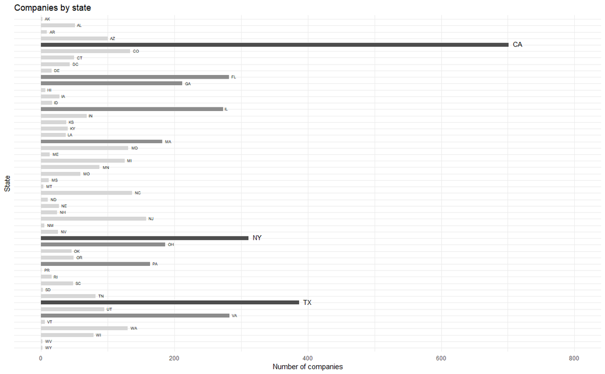

```r
# We chart states with horizontal bars representing the number of companies for each.  Top states are highlighted for ease of reference.
# Define custom monochromatic color gradient (hue, really) based on rank grouping to highlight states with most companies in the dataset - the top 3 are dark gray, the next seven are gray, and the remainder are light gray.
state_colors <- c('Top3' = 'grey30', '7-10' = 'grey55', '11-50' = 'grey84')
# Configure data for ggplot
inc %>%
  select(Name, State) %>%
  group_by(State) %>%
  tally() %>%

  # Create variables to control bar hue by state rank groupings - references: https://stackoverflow.com/questions/26106408/create-a-ranking-variable-with-dplyr and https://community.rstudio.com/t/setting-colours-in-ggplot-conditional-on-value/8328
  mutate(Ranking = dense_rank(desc(n)),
         RankGroup = cut(Ranking,
                          breaks = c(0, 3, 10, Inf),
                          labels = c('Top3', '7-10', '11-50'),
                          right = TRUE)) %>%
  # Call ggplot
  ggplot(aes(x = fct_rev(State),  # Order states reverse-alphabetically before flipping coordinate axes
             y = n,
             fill = RankGroup)) +

    # Use bar geom layer to convey differences between states
    geom_bar(stat = 'identity',
             width = .6) +

    # Color bars based on state rank grouping
    scale_fill_manual(values = state_colors) +

    # Label each state at end of bar whence eye is drawn
    geom_text(data = function(x) dplyr::filter_(x, ~ RankGroup %in% c('7-10', '11-50')),
              aes(label = State),
              size = 2,
              hjust = -.5,
              vjust = .3) +
    geom_text(data = function(x) dplyr::filter_(x, ~ RankGroup == 'Top3'), # Magnify size of labels for top 3 states
              aes(label = State),
              size = 3.7,
              hjust = -.5,
              vjust = .3) +

    # Flip axis for portrait orientation
    coord_flip(ylim = c(0, 800), expand = TRUE) +

    # Clearly label and apply muted theme for easy comprehension
    labs(title = 'Companies by state',
         x = 'State',
         y = 'Number of companies') +
    theme_minimal() +
    theme(axis.text.y = element_blank(), # Remove axis labels, annotating bar ends instead as eye is drawn there
          axis.ticks = element_blank(),  # Remove chrome / cruft
          legend.position = 'none')  # Remove surplus legend
```

```r
NA
NA
```

## Question 2

Lets dig in on the state with the 3rd most companies in the data set. Imagine you work for the state and are interested in how many people are employed by companies in different industries. Create a plot that shows the average and/or median employment by industry for companies in this state (only use cases with full data, use R’s `complete.cases()` function.) In addition to this, your graph should show how variable the ranges are, and you should deal with outliers.

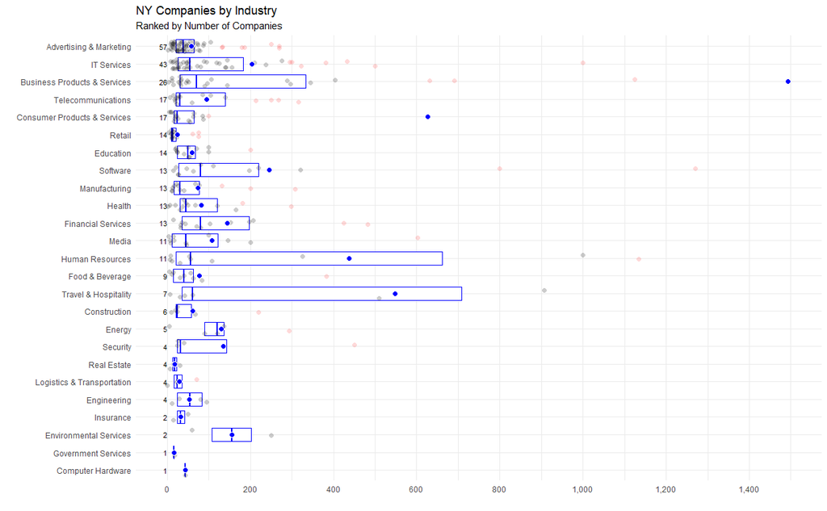

```r
# From the Q1 chart it's evident that NY is the state with the third most companies, following California and Texas.  Accordingly, we chart employees by NY state companies grouped by industry with a horizontal boxplot.  The number of employees per company are plotted on the horizontal axis; industries are plotted on the vertical axis, ranked in descending order by the number of companies in the NY state dataset.  The number of companies are marked along the vertical axis, providing an indication of observations so statistics from low sample industries are intrepreted appropriately.  The distribution density of number of employee per company is depicted by point clouds, with outliers marked in red.  The median and inter-quartile range of employees per company for each industry are represented by blue boxes, and mean employees per company is also plotted in blue to characterize the weight of outliers (for example, business products and services and consumer products and services both have means well above the IQR, reflecting skew of large outliers).  Some outliers have been excluded from view to focus users on drawing clearer contrasts in the distributions between industries.
# Instantiate function to count number of companies by industry
give.n <- function(x){
  return(c(y = 0, label = length(x)))
}
# Configure data for ggplot
inc[complete.cases(inc),] %>%
  filter(State == 'NY') %>%
  select(Name, Industry, Employees) %>%
  group_by(Industry) %>%
  # Flag employee counts by company as outliers (> IQR == 'TRUE) or not ('FALSE')
  mutate(Outlier = Employees > median(Employees) + IQR(Employees) * 1.5) %>%

  # Call ggplot
  ggplot(aes(x = reorder(Industry,
                         X = as.numeric(Employees),
                         FUN = length),  # Rank industries by number of employees - reference: https://www.rdocumentation.org/packages/DescTools/versions/0.99.19/topics/reorder.factor
             y = Employees)) +

    # Use boxplot geom layer to convey median and IQR
    geom_boxplot(color = 'blue', # Use bold blue to stand out
                 outlier.shape = NA, # Chart outliers as points through separate geom layer
                 coef = 0) +  # Remove whiskers to reduce ink, as median and point clouds better relay distribution - reference: https://stackoverflow.com/questions/18459287/remove-whiskers-in-box-whisker-plot

    # Use point geom layers to demonstrate density of distribution
    geom_point(data = function(x) dplyr::filter_(x, ~ Outlier == 'FALSE'), # Geom layer for non-outliers in black
               size = 2,
               shape = 16,
               alpha = .2,
               position = position_jitter(w = .3, h = .1)) + # Use alpha and jitter together to convey density and distribution
    geom_point(data = function(x) dplyr::filter_(x, ~ Outlier == 'TRUE'), # Geom layer for outliers in red
               size = 2,
               color = 'red',
               shape = 16,
               alpha = .15,
               position = position_jitter(w = .15, h = .1)) + # Adjust alpha jitter (less spread for lower density of points)

    # Add point at mean to mirror summary statistic cues of boxplot geom layer
    stat_summary(fun.y = 'mean',
                 geom = 'point',
                 shape = 21,
                 size = 3,
                 color = 'white', # Bold mean's perimeter white for contrast with point clouds
                 fill = 'blue') + # Use bold blue to mirror IQR boxes
    # Label number of companies for each industry along axis - references: https://stackoverflow.com/questions/28846348/add-number-of-observations-per-group-in-ggplot2-boxplot
    # https://medium.com/@gscheithauer/how-to-add-number-of-observations-to-a-ggplot2-boxplot-b22710f7ef8
    stat_summary(fun.data = give.n,
                 geom = 'text',
                 size = 3,
                 hjust = 1,
                 position = position_dodge(width = 1)) +

    # Flip axis for portrait orientation, adding chart view limits like coord_cartesian layer
    # Avoided scale_y_continuous as it filters out data from stat_summary() - reference: https://github.com/tidyverse/ggplot2/issues/647
    coord_flip(ylim = c(0, 1500), expand = TRUE) +
    scale_y_continuous(labels = scales::comma,
                       breaks = seq(0, 1600, by = 200)) +

    # Clearly label and apply muted theme for easy comprehension
    labs(title = 'NY Companies by Industry',
         subtitle = 'Ranked by Number of Companies',
         x = '',
         y = '') +
    theme_minimal()
```